# **Course Work Waze Project**

**The goal** is to use a dataframe constructed within Python, perform inspection of the data provided, and develop a machine learning model that will help prevent churn, improve user retention, and drive business growth for Waze.

# **PACE stages**

## **Plan**

### Understand the situation

##### Reading the data, exploring the dataset to identify key variables.

## **Analyze**

### **Data exploration and cleaning**

Consider the following questions:

1. Given the scenario, which data columns are most applicable?

The more relevant columns are user app usage, drives, and sessions.

### Imports and data loading

```python
# Import packages
import pandas as pd
import numpy as np
import matplotlib.pyplot as plt
import seaborn as sns

# Load dataset into dataframe
df = pd.read_csv("waze_dataset.csv")
```

### Summary information

```python
df.head(10)
```

|  | ID | label | sessions | drives | total_sessions | n_days_after_onboarding | total_navigations_fav1 | total_navigations_fav2 | driven_km_drives | duration_minutes_drives | activity_days | driving_days | device |
| --- | --- | --- | --- | --- | --- | --- | --- | --- | --- | --- | --- | --- | --- |
| 0 | 0 | retained | 283 | 226 | 296.748273 | 2276 | 208 | 0 | 2628.845068 | 1985.775061 | 28 | 19 | Android |
| 1 | 1 | retained | 133 | 107 | 326.896596 | 1225 | 19 | 64 | 13715.920550 | 3160.472914 | 13 | 11 | iPhone |
| 2 | 2 | retained | 114 | 95 | 135.522926 | 2651 | 0 | 0 | 3059.148818 | 1610.735904 | 14 | 8 | Android |
| 3 | 3 | retained | 49 | 40 | 67.589221 | 15 | 322 | 7 | 913.591123 | 587.196542 | 7 | 3 | iPhone |
| 4 | 4 | retained | 84 | 68 | 168.247020 | 1562 | 166 | 5 | 3950.202008 | 1219.555924 | 27 | 18 | Android |
| 5 | 5 | retained | 113 | 103 | 279.544437 | 2637 | 0 | 0 | 901.238699 | 439.101397 | 15 | 11 | iPhone |
| 6 | 6 | retained | 3 | 2 | 236.725314 | 360 | 185 | 18 | 5249.172828 | 726.577205 | 28 | 23 | iPhone |
| 7 | 7 | retained | 39 | 35 | 176.072845 | 2999 | 0 | 0 | 7892.052468 | 2466.981741 | 22 | 20 | iPhone |
| 8 | 8 | retained | 57 | 46 | 183.532018 | 424 | 0 | 26 | 2651.709764 | 1594.342984 | 25 | 20 | Android |
| 9 | 9 | churned | 84 | 68 | 244.802115 | 2997 | 72 | 0 | 6043.460295 | 2341.838528 | 7 | 3 | iPhone |

#### In the firts 10 observations there are not missing values.It is not the same to assume that the dataset don't have them.

```python
df.info()
```

```
<class 'pandas.core.frame.DataFrame'>
RangeIndex: 14999 entries, 0 to 14998
Data columns (total 13 columns):
 #   Column                   Non-Null Count  Dtype
---  ------                   --------------  -----
 0   ID                       14999 non-null  int64
 1   label                    14299 non-null  object
 2   sessions                 14999 non-null  int64
 3   drives                   14999 non-null  int64
 4   total_sessions           14999 non-null  float64
 5   n_days_after_onboarding  14999 non-null  int64
 6   total_navigations_fav1   14999 non-null  int64
 7   total_navigations_fav2   14999 non-null  int64
 8   driven_km_drives         14999 non-null  float64
 9   duration_minutes_drives  14999 non-null  float64
 10  activity_days            14999 non-null  int64
 11  driving_days             14999 non-null  int64
 12  device                   14999 non-null  object
dtypes: float64(3), int64(8), object(2)
memory usage: 1.5+ MB
```

There are 13 columns and 14999 entries and data types are 3 float, 8 integers, and 2 objects.

### Null values and summary statistics

```python
# Isolate rows with null values
### YOUR CODE HERE ###
null_df = df[df['label'].isnull()]
null_df.describe()
```

|  | ID | sessions | drives | total_sessions | n_days_after_onboarding | total_navigations_fav1 | total_navigations_fav2 | driven_km_drives | duration_minutes_drives | activity_days | driving_days |
| --- | --- | --- | --- | --- | --- | --- | --- | --- | --- | --- | --- |
| count | 700.000000 | 700.000000 | 700.000000 | 700.000000 | 700.000000 | 700.000000 | 700.000000 | 700.000000 | 700.000000 | 700.000000 | 700.000000 |
| mean | 7405.584286 | 80.837143 | 67.798571 | 198.483348 | 1709.295714 | 118.717143 | 30.371429 | 3935.967029 | 1795.123358 | 15.382857 | 12.125714 |
| std | 4306.900234 | 79.987440 | 65.271926 | 140.561715 | 1005.306562 | 156.308140 | 46.306984 | 2443.107121 | 1419.242246 | 8.772714 | 7.626373 |
| min | 77.000000 | 0.000000 | 0.000000 | 5.582648 | 16.000000 | 0.000000 | 0.000000 | 290.119811 | 66.588493 | 0.000000 | 0.000000 |
| 25% | 3744.500000 | 23.000000 | 20.000000 | 94.056340 | 869.000000 | 4.000000 | 0.000000 | 2119.344818 | 779.009271 | 8.000000 | 6.000000 |
| 50% | 7443.000000 | 56.000000 | 47.500000 | 177.255925 | 1650.500000 | 62.500000 | 10.000000 | 3421.156721 | 1414.966279 | 15.000000 | 12.000000 |
| 75% | 11007.000000 | 112.250000 | 94.000000 | 266.058022 | 2508.750000 | 169.250000 | 43.000000 | 5166.097373 | 2443.955404 | 23.000000 | 18.000000 |
| max | 14993.000000 | 556.000000 | 445.000000 | 1076.879741 | 3498.000000 | 1096.000000 | 352.000000 | 15135.391280 | 9746.253023 | 31.000000 | 30.000000 |

```python
# Isolate rows with null values
not_null_df =df[~df['label'].isnull()]
# Display summary stats of rows without null values
not_null_df.describe()
```

|  | ID | sessions | drives | total_sessions | n_days_after_onboarding | total_navigations_fav1 | total_navigations_fav2 | driven_km_drives | duration_minutes_drives | activity_days | driving_days |
| --- | --- | --- | --- | --- | --- | --- | --- | --- | --- | --- | --- |
| count | 14299.000000 | 14299.000000 | 14299.000000 | 14299.000000 | 14299.000000 | 14299.000000 | 14299.000000 | 14299.000000 | 14299.000000 | 14299.000000 | 14299.000000 |
| mean | 7503.573117 | 80.623820 | 67.255822 | 189.547409 | 1751.822505 | 121.747395 | 29.638296 | 4044.401535 | 1864.199794 | 15.544653 | 12.182530 |
| std | 4331.207621 | 80.736502 | 65.947295 | 136.189764 | 1008.663834 | 147.713428 | 45.350890 | 2504.977970 | 1448.005047 | 9.016088 | 7.833835 |
| min | 0.000000 | 0.000000 | 0.000000 | 0.220211 | 4.000000 | 0.000000 | 0.000000 | 60.441250 | 18.282082 | 0.000000 | 0.000000 |
| 25% | 3749.500000 | 23.000000 | 20.000000 | 90.457733 | 878.500000 | 10.000000 | 0.000000 | 2217.319909 | 840.181344 | 8.000000 | 5.000000 |
| 50% | 7504.000000 | 56.000000 | 48.000000 | 158.718571 | 1749.000000 | 71.000000 | 9.000000 | 3496.545617 | 1479.394387 | 16.000000 | 12.000000 |
| 75% | 11257.500000 | 111.000000 | 93.000000 | 253.540450 | 2627.500000 | 178.000000 | 43.000000 | 5299.972162 | 2466.928876 | 23.000000 | 19.000000 |
| max | 14998.000000 | 743.000000 | 596.000000 | 1216.154633 | 3500.000000 | 1236.000000 | 415.000000 | 21183.401890 | 15851.727160 | 31.000000 | 30.000000 |

#### Standard deviations are fairly consistent between the two groups.

### Null values - devices couts

```python
# Get count of null values by device
null_df['device'].value_counts()
```

```
device
iPhone     447
Android    253
Name: count, dtype: int64
```

```python
# Calculate % of iPhone nulls and Android nulls
null_df['device'].value_counts(normalize=True)
```

```
device
iPhone     0.638571
Android    0.361429
Name: proportion, dtype: float64
```

```python
# Calculate % of iPhone users and Android users in the full dataset
df['device'].value_counts(normalize=True)
```

```
device
iPhone     0.644843
Android    0.355157
Name: proportion, dtype: float64
```

#### Examine the counts and percentages of users who churned vs. those who were retained. How many of each group are represented in the data?

```python
# Calculate counts of churned vs. retained
print(df['label'].value_counts())
print()
print(df['label'].value_counts(normalize=True))
```

```
label
retained    11763
churned      2536
Name: count, dtype: int64

label
retained    0.822645
churned     0.177355
Name: proportion, dtype: float64
```

#### This dataset contains 82% retained users and 18% churned users.

```python
# Calculate median values of all columns for churned and retained users
df.groupby('label').median(numeric_only=True)
```

[output not shown]

```python
# Add a column to df called 'km_per_driving_day'
df['km_per_drive']= df['driven_km_drives'] / df['drives']

# Group by 'label', calculate the median, and isolate for km per drive
median_km_per_drive = df.groupby('label').median(numeric_only=True)[['km_per_drive']]
median_km_per_drive
```

| label | km_per_drive |
| --- | --- |
| churned | 74.109416 |
| retained | 75.014702 |

#### The median retained user drove about one more kilometer per drive than the median churned user. How many kilometers per driving day was this?

```python
# Add a column to df called 'km_per_driving_day'
df['km_per_driving_day'] = df['driven_km_drives'] / df['driving_days']

# Group by 'label', calculate the median, and isolate for km per driving day
median_km_per_driving_day = df.groupby('label').median(numeric_only=True)[['km_per_driving_day']]
median_km_per_driving_day
```

| label | km_per_driving_day |
| --- | --- |
| churned | 697.541999 |
| retained | 289.549333 |

```python
# Add a column to df called 'drives_per_driving_day'
df['drives_per_driving_day'] = df['drives'] / df['driving_days']

# Group by 'label', calculate the median, and isolate for drives per driving day
median_drives_per_driving_day = df.groupby('label').median(numeric_only=True)[['drives_per_driving_day']]
median_drives_per_driving_day
```

| label | drives_per_driving_day |
| --- | --- |
| churned | 10.0000 |
| retained | 4.0625 |

#### The median user who churned drove 698 kilometers each day they drove last month, which is ~240% the per-drive-day distance of retained users. The median churned user had a similarly disproporionate number of drives per drive day compared to retained users.

#### It is clear from these figures that, regardless of whether a user churned or not, the users represented in this data are serious drivers! It would probably be safe to assume that this data does not represent typical drivers at large. Perhaps the data—and in particular the sample of churned users—contains a high proportion of long-haul truckers.

#### In consideration of how much these users drive, it would be worthwhile to recommend to Waze that they gather more data on these super-drivers. It's possible that the reason for their driving so much is also the reason why the Waze app does not meet their specific set of needs, which may differ from the needs of a more typical driver, such as a commuter.

#### Finally, examine whether there is an imbalance in how many users churned by device type.

#### Begin by getting the overall counts of each device type for each group, churned and retained.

```python
# For each label, calculate the number of Android users and iPhone users
df.groupby(['label','device']).size()
```

```
label     device
churned   Android     891
          iPhone     1645
retained  Android    4183
          iPhone     7580
dtype: int64
```

#### Now, within each group, churned and retained, calculate what percent was Android and what percent was iPhone.

```python
# For each label, calculate the percentage of Android users and iPhone users
df.groupby('label')['device'].value_counts(normalize=True)
```

```
label     device
churned   iPhone     0.648659
          Android    0.351341
retained  iPhone     0.644393
          Android    0.355607
Name: proportion, dtype: float64
```

Did the data contain any missing values? How many, and which variables were affected? Was there a pattern to the missing data? The dataset has 700 missing values in the label column. There was no obvious pattern to the missing values.

What is a benefit of using the median value of a sample instead of the mean? Mean is subject to the influence of outliers, while the median represents the middle value of the distribution regardless of any outlying values.

Did your investigation give rise to further questions that you would like to explore or ask the Waze team about? Yes. For example, the median user who churned drove 698 kilometers each day they drove last month, which is about 240% the per-drive-day distance of retained users. It would be helpful to know how this data was collected and if it represents a non-random sample of users.

What percentage of the users in the dataset were Android users and what percentage were iPhone users? Android users comprised approximately 36% of the sample, while iPhone users made up about 64%

What were some distinguishing characteristics of users who churned vs. users who were retained? Generally, users who churned drove farther and longer in fewer days than retained users. They also used the app about half as many times as retained users over the same period.

Was there an appreciable difference in churn rate between iPhone users vs. Android users? No. The churn rate for both iPhone and Android users was within one percentage point of each other. There is nothing suggestive of churn being correlated with device.

## **Construct**

### Visualizations

#### Number of occurrence oa a user opening the app during the month

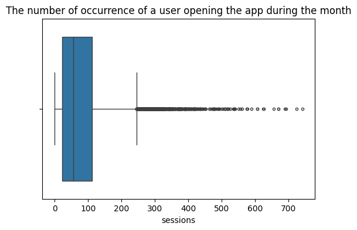

```python
# Box plot
### YOUR CODE HERE ###
plt.figure(figsize=(6,4))
plt.title('The number of occurrence of a user opening the app during the month')
sns.boxplot(data=None, x=df['sessions'], fliersize=3);
```

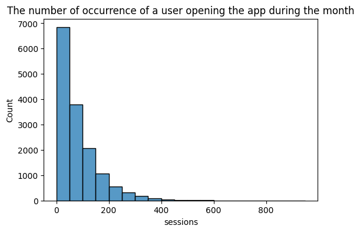

```python
# Histogram
### YOUR CODE HERE ###
plt.figure(figsize=(6,4))
sns.histplot(df['sessions'], bins=range(0,1000,50))
plt.title('The number of occurrence of a user opening the app during the month');
```

### Drives

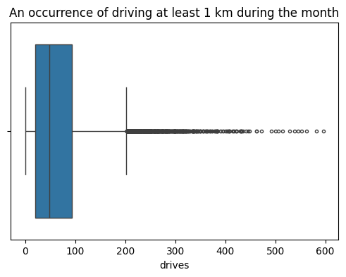

```python
# Box plot
### YOUR CODE HERE ###
plt.figure(figsize=(6,4))
plt.title('An occurrence of driving at least 1 km during the month')
sns.boxplot(data=None, x=df['drives'], fliersize=3);
```

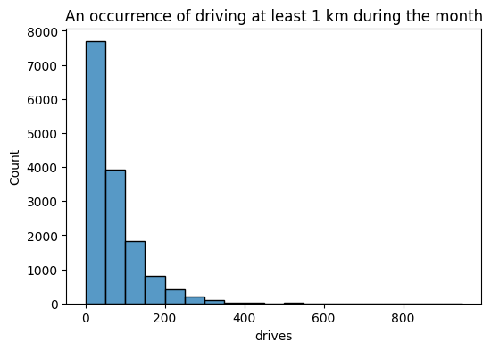

```python
# Histogram
### YOUR CODE HERE ###
plt.figure(figsize=(6,4))
sns.histplot(df['drives'], bins=range(0,1000,50))
plt.title('An occurrence of driving at least 1 km during the month');
```